# Introduction to Exponential-family Random Graph Models with `ergm`

The Statnet Development Team

`ergm` version 4.12.0 (2026-02-17)

## Introduction

This vignette provides an introduction to statistical modeling of network data with *Exponential family Random Graph Models* (ERGMs) using `ergm` package. It is based on the `ergm` tutorial used in the `statnet` workshops, but covers a subset of that material.  
The complete tutorial can be found on the [`statnet` workshops page](https://statnet.org/workshops/).

A more complete overview of the advanced functionality available in the `ergm` package can be found in Krivitsky et al. (2023).

### Software installation

If you are reading this, you have probably already installed the `ergm` package. But in case you need to do that:

```r
install.packages('ergm')
```

```r
library(ergm)
```

Set a seed for simulations – this is not necessary, but it ensures that you will get the same results as this vignette (if you execute the same commands in the same order).

```r
set.seed(0)
```

## 1. Statistical network modeling with ERGMs

This is a *very brief* overview of the modeling framework, as the primary purpose of this tutorial is to show how to implement statistical analysis of network data with ERGMs using the `ergm` package. For more detail (and to really understand ERGMs) please see further reading at the end of this tutorial.

Exponential-family random graph models (ERGMs) are a general class of models based on exponential-family theory for specifying the tie probability distribution for a set of random graphs or networks. Within this framework, one can—among other tasks:

- Define a model for a network that includes covariates representing features like nodal attribute homophily, mutuality, triad effects, and a wide range of other structural features of interest;
- Obtain maximum-likehood estimates for the parameters of the specified model for a given data set;
- Test the statistical significance of individual coefficients, assess models for convergence and goodness-of-fit and perform various types of model comparison; and
- Simulate new networks from the underlying probability distribution implied by the fitted model.

### The general form for an ERGM

ERGMs are a class of models, like linear regression or GLMs. The general form of the model specifies the probability of the entire network (on the left hand side), as a function of terms that represent network features we hypothesize may occur more or less likely than expected by chance (on the right hand side). The general form of the model can be written as:

$$P(Y=y)=\frac{\exp(\theta'g(y))}{k(\theta)}$$

where

- $Y$ is the random variable for the state of the network (with realization $y$),
- $g(y)$ is a vector of model statistics (“ERGM terms”) for network $y$,
- $\theta$ is the vector of coefficients for those statistics, and
- $k(\theta)$ represents the quantity in the numerator summed over all possible networks (typically constrained to be all networks with the same node set as $y$).

If you’re not familiar with the compact notation here, note that the numerator represents a formula that is linear in the log form:

$$\log({\exp(\theta'g(y))}) = \theta_1g_1(y) + \theta_2g_2(y)+ ... +
\theta_pg_p(y)$$
where $p$ is the number of terms in the model. From this one can more easily observe the analogy to a traditional statistical model: the coefficients $\theta$ represent the size and direction of the effects of the covariates $g(y)$ on the overall probability of the network.

#### The model statistics $g(y)$: ERGM terms

The statistics $g(y)$ can be thought of as the “covariates” in the model. In the network modeling context, these represent network features like density, homophily, triads, etc. In one sense, they are like covariates you might use in other statistical models. But they are different in one important respect: these $g(y)$ statistics are functions of the network itself – each is defined by the frequency of a specific configuration of dyads observed in the network – so they are not measured by a question you include in a survey (e.g., the income of a node), but instead need to be computed on the specific network you have, after you have collected the data.

As a result, every term in an ERGM must have an associated algorithm for computing its value for your network. The `ergm` package in `statnet` includes about 150 term-computing algorithms. We will explore some of these terms in this tutorial. You can get the list of all available terms, and the syntax for using them, by typing:

```r
? ergmTerm
```

and you can look up help for a specific term, say, `edges`, by typing:

```r
ergmTerm?edges
```

You can also search for terms with keywords:

```r
search.ergmTerms(keyword='homophily')
```

```
## Found  0  matching ergm terms:
```

For more information, see the vignette on `ergm` terms:

```r
vignette('ergm-term-crossRef')
```

One key distinction in model terms is worth keeping in mind: terms are either *dyad independent* or *dyad dependent*.

- Dyad *independent* terms (like nodal homophily terms) imply no dependence between dyads—the presence or absence of a tie may depend on nodal attributes, but not on the state of other ties.
- Dyad *dependent* terms (like degree terms, or triad terms), by contrast, imply dependence between dyads. Such terms have very different effects, and much of what is different about network models comes from these terms. They introduce complex cascading effects that can often lead to counter-intuitive and highly non-linear outcomes. In addition, a model with dyad dependent terms requires a different estimation algorithm, so when we use them below you will see some different components in the output.

An overview and discussion of many of these terms can be found in Morris, Handcock, and Hunter (2008).

#### Coding new `ergm` terms

There is a `statnet` package — `ergm.userterms` — that facilitates the writing of new `ergm` terms. The package is available [on GitHub](https://github.com/statnet/ergm.userterms), and installing it will include the tutorial (ergmuserterms.pdf). The tutorial can also be found in Hunter, Goodreau, and Handcock (2013), and some introductory slides and installation instructions from the workshop we teach on coding `ergm` terms can be found [here](https://statnet.org/workshops/). For the most recent API available for implementing terms, see the Terms API vignette.

Note that writing up new `ergm` terms requires some knowledge of C and the ability to build R from source. While the latter is covered in the tutorial, the many environments for building R and the rapid changes in these environments make these instructions obsolete quickly.

#### ERGM probabilities: at the tie-level

The ERGM expression for the probability of the entire graph shown above can be re-expressed in terms of the conditional log-odds of a single tie between two actors:

$$\operatorname{logit}{(Y_{ij}=1|y^{c}_{ij})=\theta'\delta(y_{ij})}$$

where

- $Y_{ij}$ is the random variable for the state of the actor pair $i,j$ (with realization $y_{ij}$), and
- $y^{c}_{ij}$ signifies the complement of $y_{ij}$, i.e. all dyads in the network other than $y_{ij}$.
- $\delta(y_{ij})$ is a vector of the “change statistics” for each model term. The change statistic records how the $g(y)$ term changes if the $y_{ij}$ tie is toggled on or off. So:

$$\delta(y_{ij}) = g(y^{+}_{ij})-g(y^{-}_{ij})$$

where

- $y^{+}_{ij}$ is defined as $y^{c}_{ij}$ along with $y_{ij}$ set to 1, and
- $y^{-}_{ij}$ is defined as $y^{c}_{ij}$ along with $y_{ij}$ set to 0.

So $\delta(y_{ij})$ equals the value of $g(y)$ when $y_{ij}=1$ minus the value of $g(y)$ when $y_{ij}=0$, but all other dyads are as in $y$.

This expression shows that the coefficient $\theta$ can be interpreted as that term’s contribution to the log-odds of an individual tie, conditional on all other dyads remaining the same. The coefficient for each term in the model is multiplied by the number of configurations that tie will create (or remove) for that specific term.

#### The `summary` and `ergm` functions, and supporting functions

We’ll start by running some simple models to demonstrate the most commonly used functions for ERG modeling.

The syntax for specifying a model in the `ergm` package follows **R**’s formula convention:

$$my.network \sim
my.vector.of.model.terms$$

This syntax is used for both the `summary` and `ergm` functions. The `summary` function simply returns the numerical values of the network statistics in the model. The `ergm` function estimates the model with those statistics.

It is good practice to always run a `summmary` command on a model before fitting it with `ergm`. This is the ERGM equivalent of performing some descriptive analysis on your covariates. This can help you make sure you understand what the term represents, and it can help to flag potential problems that will lead to poor modeling results.

### Network data

Network data can come in many different forms – as adjacency matrices, edgelists and data frames. For use with `ergm` these need to be converted into a `network` class object. The `network` package provides the utilities for this, and more information can be found in the examples and vignette there.

```r
vignette("networkVignette")
```

Here, we will use some of the network objects included with the `ergm` package.

```r
data(package='ergm') # tells us the datasets in our packages
```

### Model specification

We’ll start with Padgett’s data on Renaissance Florentine families for our first example. As with all data analysis, we start by looking at our data using graphical and numerical descriptives.

```r
data(florentine) # loads flomarriage and flobusiness data
flomarriage # Look at the flomarriage network properties (uses `network`), esp. the vertex attributes
```

```
##  Network attributes:
##   vertices = 16
##   directed = FALSE
##   hyper = FALSE
##   loops = FALSE
##   multiple = FALSE
##   bipartite = FALSE
##   total edges= 20
##     missing edges= 0
##     non-missing edges= 20
##
##  Vertex attribute names:
##     priorates totalties vertex.names wealth
##
## No edge attributes
```

```r
plot(flomarriage,
     main="Florentine Marriage",
     cex.main=0.8,
     label = network.vertex.names(flomarriage)) # Plot the network
wealth <- flomarriage %v% 'wealth' # %v% references vertex attributes
wealth
```

```
##  [1]  10  36  55  44  20  32   8  42 103  48  49   3  27  10 146  48
```

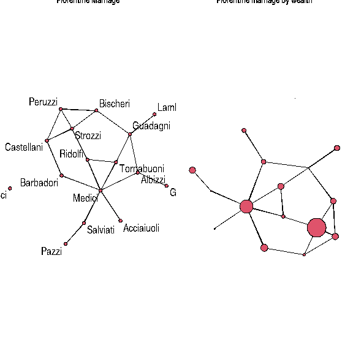

```r
plot(flomarriage,
     vertex.cex=wealth/25,
     main="Florentine marriage by wealth", cex.main=0.8) # Plot the network with vertex size proportional to wealth
```

#### A simple Bernoulli (“Erdos/Renyi”) model

We begin with a simple model, containing only one term that represents the total number of edges in the network, $\sum{y_{ij}}$. The name of this `ergm` term is `edges`, and when included in an ERGM its coefficient controls the overall density of the network.

```r
summary(flomarriage ~ edges) # Look at the $g(y)$ statistic for this model
```

```
## edges
##    20
```

```r
flomodel.01 <- ergm(flomarriage ~ edges) # Estimate the model
```

```
## Starting maximum pseudolikelihood estimation (MPLE):
```

```
## Obtaining the responsible dyads.
```

```
## Evaluating the predictor and response matrix.
```

```
## Maximizing the pseudolikelihood.
```

```
## Finished MPLE.
```

```
## Evaluating log-likelihood at the estimate.
```

```r
summary(flomodel.01) # Look at the fitted model object
```

```
## Call:
## ergm(formula = flomarriage ~ edges)
##
## Maximum Likelihood Results:
##
##       Estimate Std. Error MCMC % z value Pr(>|z|)
## edges  -1.6094     0.2449      0  -6.571   <1e-04 ***
## ---
## Signif. codes:  0 '***' 0.001 '**' 0.01 '*' 0.05 '.' 0.1 ' ' 1
##
##      Null Deviance: 166.4  on 120  degrees of freedom
##  Residual Deviance: 108.1  on 119  degrees of freedom
##
## AIC: 110.1  BIC: 112.9  (Smaller is better. MC Std. Err. = 0)
```

This simple model specifies a single homogeneous probability for all ties, which is captured by the coefficient of the `edges` term. How should we interpret this coefficient? The easiest way is to return to the logit form of the ERGM. The log-odds that a tie is present is
$$\begin{align*}
\operatorname{logit}(p(y)) &= \theta \times \delta(g(y)) \\
& = -1.61 \times \mbox{change in the number of ties}\\
& = -1.61 \times 1
\end{align*}$$
for every tie, since the addition of any tie to the network always increases the total number of ties by 1.

The corresponding probability is obtained by taking the expit, or inverse logit, of $\theta$:
$$\begin{align*}
& = \exp(-1.61)/
(1+\exp(-1.61))\\
& = 0.17
\end{align*}$$
This probability corresponds to the density we observe in the flomarriage network: there are $20$ ties and $\binom{16}{2} = (16 \times 15)/2 = 120$ dyads, so the probability of a tie is $20/120 = 0.17$.

#### Triad formation

Let’s add a term often thought to be a measure of “clustering”: the number of completed triangles in the network, or $\sum{y_{ij}y_{ik}y_{jk}} \div 3$.  
The name for this `ergm` term is `triangle`.

This is an example of a dyad dependent term: The status of any triangle containing dyad $y_{ij}$ depends on the status of dyads of the form $y_{ik}$ and $y_{jk}$. This means that any model containing the `ergm` term `triangle` has the property that dyads are not probabilistically independent of one another. As a result, the estimation algorithm automatically changes to MCMC, and because this is a form of stochastic estimation your results may differ slightly.

```r
summary(flomarriage~edges+triangle) # Look at the g(y) stats for this model
```

```
##    edges triangle
##       20        3
```

```r
flomodel.02 <- ergm(flomarriage~edges+triangle)
summary(flomodel.02)
```

```
## Call:
## ergm(formula = flomarriage ~ edges + triangle)
##
## Monte Carlo Maximum Likelihood Results:
##
##          Estimate Std. Error MCMC % z value Pr(>|z|)
## edges     -1.6525     0.3502      0  -4.718   <1e-04 ***
## triangle   0.1676     0.5766      0   0.291    0.771
## ---
## Signif. codes:  0 '***' 0.001 '**' 0.01 '*' 0.05 '.' 0.1 ' ' 1
##
##      Null Deviance: 166.4  on 120  degrees of freedom
##  Residual Deviance: 108.1  on 118  degrees of freedom
##
## AIC: 112.1  BIC: 117.7  (Smaller is better. MC Std. Err. = 0.01244)
```

Now, how should we interpret coefficients?

The conditional log-odds of two actors having a tie, keeping the rest of the network fixed, is
$$-1.65 \times\mbox{change in the number of ties} + 0.17
\times\mbox{change in number of triangles.}$$

- For a tie that will create no triangles, the conditional log-odds is: $-1.65$.
- if one triangle: $-1.65 + 0.17 = -1.48$
- if two triangles: $-1.65 + 2 \times0.17 = -1.32$
- the corresponding probabilities are 0.16, 0.18, and 0.20.

Let’s take a closer look at the ergm object that the function outputs:

```r
class(flomodel.02) # this has the class ergm
```

```
## [1] "ergm"
```

```r
names(flomodel.02) # the ERGM object contains lots of components.
```

```
##  [1] "coefficients"    "sample"          "iterations"
##  [4] "MCMCtheta"       "loglikelihood"   "gradient"
##  [7] "hessian"         "covar"           "failure"
## [10] "newnetwork"      "coef.init"       "est.cov"
## [13] "coef.hist"       "stats.hist"      "steplen.hist"
## [16] "control"         "etamap"          "MCMCflag"
## [19] "lindep"          "nw.stats"        "call"
## [22] "network"         "ergm_version"    "info"
## [25] "MPLE_is_MLE"     "drop"            "offset"
## [28] "estimable"       "formula"         "reference"
## [31] "constraints"     "obs.constraints" "estimate"
## [34] "estimate.desc"   "null.lik"        "mle.lik"
```

```r
coef(flomodel.02) # you can extract/inspect individual components
```

```
##      edges   triangle
## -1.6524648  0.1676376
```

#### Nodal covariates: effects on mean degree

We saw earlier that wealth appeared to be associated with higher degree in this network. We can use `ergm` to test this. Wealth is a nodal covariate, so we use the `ergm` term `nodecov`.

```r
summary(wealth) # summarize the distribution of wealth
```

```
##    Min. 1st Qu.  Median    Mean 3rd Qu.    Max.
##    3.00   17.50   39.00   42.56   48.25  146.00
```

```r
# plot(flomarriage,
#      vertex.cex=wealth/25,
#      main="Florentine marriage by wealth",
#      cex.main=0.8) # network plot with vertex size proportional to wealth
summary(flomarriage~edges+nodecov('wealth')) # observed statistics for the model
```

```
##          edges nodecov.wealth
##             20           2168
```

```r
flomodel.03 <- ergm(flomarriage~edges+nodecov('wealth'))
```

```
## Starting maximum pseudolikelihood estimation (MPLE):
```

```
## Obtaining the responsible dyads.
```

```
## Evaluating the predictor and response matrix.
```

```
## Maximizing the pseudolikelihood.
```

```
## Finished MPLE.
```

```
## Evaluating log-likelihood at the estimate.
```

```r
summary(flomodel.03)
```

```
## Call:
## ergm(formula = flomarriage ~ edges + nodecov("wealth"))
##
## Maximum Likelihood Results:
##
##                 Estimate Std. Error MCMC % z value Pr(>|z|)
## edges          -2.594929   0.536056      0  -4.841   <1e-04 ***
## nodecov.wealth  0.010546   0.004674      0   2.256   0.0241 *
## ---
## Signif. codes:  0 '***' 0.001 '**' 0.01 '*' 0.05 '.' 0.1 ' ' 1
##
##      Null Deviance: 166.4  on 120  degrees of freedom
##  Residual Deviance: 103.1  on 118  degrees of freedom
##
## AIC: 107.1  BIC: 112.7  (Smaller is better. MC Std. Err. = 0)
```

And yes, there is a significant positive wealth effect on the probability of a tie.

*Question:* What does the value of the **nodecov** statistic represent?

How do we interpret the coefficients here? Note that the wealth effect operates on both nodes in a dyad. The conditional log-odds of a tie between two actors is:
$$-2.59\times\mbox{change in the number of ties} + 0.01\times\mbox{the
wealth of node 1} + 0.01\times\mbox{the wealth of node 2}$$
or
$$-2.59\times\mbox{change in the number of ties} + 0.01\times\mbox{the sum
of the wealth of the two nodes}.$$

- for a tie between two nodes with minimum wealth, the conditional log-odds is:  
  $-2.59 + 0.01*(3+3) = -2.53$
- for a tie between two nodes with maximum wealth:  
  $-2.59 + 0.01*(146+146) = 0.33$
- for a tie between the node with maximum wealth and the node with minimum wealth:  
  $-2.59 + 0.01*(146+3) = -1.1$
- The corresponding probabilities are 0.07, 0.58, and 0.25.

This model specification does not include a term for homophily by wealth, i.e., a term accounting for similarity in wealth of the two end nodes of a potential tie. It just specifies a relation between wealth and mean degree. To specify homophily on wealth, you could use the `ergm` term `absdiff`.

#### Nodal covariates: Homophily

Let’s try a larger network, a simulated mutual friendship network based on one of the schools from the AddHealth study. Here, we’ll examine the homophily in friendships by grade and race. Both are discrete attributes so we use the `ergm` term `nodematch`.

```r
data(faux.mesa.high)
mesa <- faux.mesa.high
```

```r
mesa
```

```
##  Network attributes:
##   vertices = 205
##   directed = FALSE
##   hyper = FALSE
##   loops = FALSE
##   multiple = FALSE
##   bipartite = FALSE
##   total edges= 203
##     missing edges= 0
##     non-missing edges= 203
##
##  Vertex attribute names:
##     Grade Race Sex
##
## No edge attributes
```

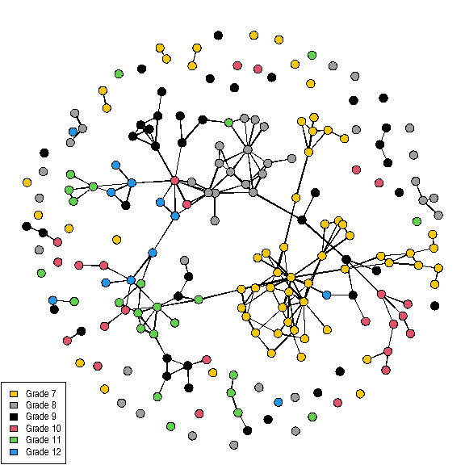

```r
plot(mesa, vertex.col='Grade')
legend('bottomleft',fill=7:12,
       legend=paste('Grade',7:12),cex=0.75)
```

```r
fauxmodel.01 <- ergm(mesa ~edges +
                       nodefactor('Grade') + nodematch('Grade',diff=T) +
                       nodefactor('Race') + nodematch('Race',diff=T))
```

```
## Observed statistic(s) nodematch.Race.Black and nodematch.Race.Other are at their smallest attainable values. Their coefficients will be fixed at -Inf.
```

```
## Starting maximum pseudolikelihood estimation (MPLE):
```

```
## Obtaining the responsible dyads.
```

```
## Evaluating the predictor and response matrix.
```

```
## Maximizing the pseudolikelihood.
```

```
## Finished MPLE.
```

```
## Evaluating log-likelihood at the estimate.
```

```r
summary(fauxmodel.01)
```

```
## Call:
## ergm(formula = mesa ~ edges + nodefactor("Grade") + nodematch("Grade",
##     diff = T) + nodefactor("Race") + nodematch("Race", diff = T))
##
## Maximum Likelihood Results:
##
##                       Estimate Std. Error MCMC % z value Pr(>|z|)
## edges                  -8.0538     1.2561      0  -6.412  < 1e-04 ***
## nodefactor.Grade.8      1.5201     0.6858      0   2.216 0.026663 *
## nodefactor.Grade.9      2.5284     0.6493      0   3.894  < 1e-04 ***
## nodefactor.Grade.10     2.8652     0.6512      0   4.400  < 1e-04 ***
## nodefactor.Grade.11     2.6291     0.6563      0   4.006  < 1e-04 ***
## nodefactor.Grade.12     3.4629     0.6566      0   5.274  < 1e-04 ***
## nodematch.Grade.7       7.4662     1.1730      0   6.365  < 1e-04 ***
## nodematch.Grade.8       4.2882     0.7150      0   5.997  < 1e-04 ***
## nodematch.Grade.9       2.0371     0.5538      0   3.678 0.000235 ***
## nodematch.Grade.10      1.2489     0.6233      0   2.004 0.045111 *
## nodematch.Grade.11      2.4521     0.6124      0   4.004  < 1e-04 ***
## nodematch.Grade.12      1.2987     0.6981      0   1.860 0.062824 .
## nodefactor.Race.Hisp   -1.6659     0.2963      0  -5.622  < 1e-04 ***
## nodefactor.Race.NatAm  -1.4725     0.2869      0  -5.132  < 1e-04 ***
## nodefactor.Race.Other  -2.9618     1.0372      0  -2.856 0.004296 **
## nodefactor.Race.White  -0.8488     0.2958      0  -2.869 0.004112 **
## nodematch.Race.Black      -Inf     0.0000      0    -Inf  < 1e-04 ***
## nodematch.Race.Hisp     0.6912     0.3451      0   2.003 0.045153 *
## nodematch.Race.NatAm    1.2482     0.3550      0   3.517 0.000437 ***
## nodematch.Race.Other      -Inf     0.0000      0    -Inf  < 1e-04 ***
## nodematch.Race.White    0.3140     0.6405      0   0.490 0.623947
## ---
## Signif. codes:  0 '***' 0.001 '**' 0.01 '*' 0.05 '.' 0.1 ' ' 1
##
##      Null Deviance: 28987  on 20910  degrees of freedom
##  Residual Deviance:  1798  on 20889  degrees of freedom
##
## AIC: 1836  BIC: 1987  (Smaller is better. MC Std. Err. = 0)
## Warnings:
##
##  * The following terms have infinite coefficient estimates due to
##    an extreme sufficient statistic:
##
##    nodematch.Race.Black, nodematch.Race.Other
```

Note that two of the coefficients are estimated as -Inf (the nodematch coefficients for race Black and Other). Why is this?

```r
table(mesa %v% 'Race') # Frequencies of race
```

```
##
## Black  Hisp NatAm Other White
##     6   109    68     4    18
```

```r
mixingmatrix(mesa, "Race")
```

```
##       Black Hisp NatAm Other White
## Black     0    8    13     0     5
## Hisp      8   53    41     1    22
## NatAm    13   41    46     0    10
## Other     0    1     0     0     0
## White     5   22    10     0     4
```

```
## Note:  Marginal totals can be misleading for undirected mixing matrices.
```

The problem is that there are very few students in the Black and Other race categories, and these few students form no within-group ties. The empty cells are what produce the -Inf estimates.

Note that we would have caught this earlier if we had looked at the $g(y)$ stats at the beginning:

```r
summary(mesa ~edges  +
          nodefactor('Grade') + nodematch('Grade',diff=T) +
          nodefactor('Race') + nodematch('Race',diff=T))
```

```
##                 edges    nodefactor.Grade.8    nodefactor.Grade.9
##                   203                    75                    65
##   nodefactor.Grade.10   nodefactor.Grade.11   nodefactor.Grade.12
##                    36                    49                    28
##     nodematch.Grade.7     nodematch.Grade.8     nodematch.Grade.9
##                    75                    33                    23
##    nodematch.Grade.10    nodematch.Grade.11    nodematch.Grade.12
##                     9                    17                     6
##  nodefactor.Race.Hisp nodefactor.Race.NatAm nodefactor.Race.Other
##                   178                   156                     1
## nodefactor.Race.White  nodematch.Race.Black   nodematch.Race.Hisp
##                    45                     0                    53
##  nodematch.Race.NatAm  nodematch.Race.Other  nodematch.Race.White
##                    46                     0                     4
```

**Moral**: It’s important to check the descriptive statistics of a model in the observed network before fitting the model.

See also the `ergm` terms `nodemix` and `mm` for fitting mixing patterns other than homophily on discrete nodal attributes.

#### Directed ties

Let’s try a model for a directed network, and examine the tendency for ties to be reciprocated (“mutuality”). The `ergm` term for this is `mutual`. We’ll fit this model to the third wave of the classic Sampson Monastery data, and we’ll start by taking a look at the network.

```r
data(samplk)
ls() # directed data: Sampson's Monks
```

```
##  [1] "faux.mesa.high" "fauxmodel.01"   "flobusiness"    "flomarriage"
##  [5] "flomodel.01"    "flomodel.02"    "flomodel.03"    "mesa"
##  [9] "sampdlk1"       "sampdlk2"       "sampdlk3"       "samplk1"
## [13] "samplk2"        "samplk3"        "terms"          "wealth"
```

```r
samplk3
```

```
##  Network attributes:
##   vertices = 18
##   directed = TRUE
##   hyper = FALSE
##   loops = FALSE
##   multiple = FALSE
##   bipartite = FALSE
##   total edges= 56
##     missing edges= 0
##     non-missing edges= 56
##
##  Vertex attribute names:
##     cloisterville group group3 group4 vertex.names
##
##  Edge attribute names:
##     score
```

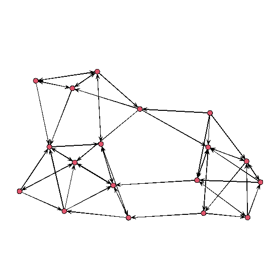

```r
plot(samplk3)
```

```r
summary(samplk3~edges+mutual)
```

```
##  edges mutual
##     56     15
```

The plot now shows the direction of a tie, and the $g(y)$ statistics for this model in this network are 56 total ties and 15 mutual dyads. This means 30 of the 56 ties are reciprocated, i.e., they are part of dyads in which both directional ties are present.

```r
sampmodel.01 <- ergm(samplk3~edges+mutual)
summary(sampmodel.01)
```

```
## Call:
## ergm(formula = samplk3 ~ edges + mutual)
##
## Monte Carlo Maximum Likelihood Results:
##
##        Estimate Std. Error MCMC % z value Pr(>|z|)
## edges   -2.1259     0.2133      0  -9.968   <1e-04 ***
## mutual   2.2540     0.4886      0   4.613   <1e-04 ***
## ---
## Signif. codes:  0 '***' 0.001 '**' 0.01 '*' 0.05 '.' 0.1 ' ' 1
##
##      Null Deviance: 424.2  on 306  degrees of freedom
##  Residual Deviance: 267.6  on 304  degrees of freedom
##
## AIC: 271.6  BIC: 279  (Smaller is better. MC Std. Err. = 0.3466)
```

Triangle terms in directed networks can have many different configurations, given the directional ties. Many of these configurations are coded as `ergm` terms (and we’ll talk about these more below).

## 2. Missing data

It is important to distinguish between the absence of a tie and the absence of data on whether a tie exists. The former is an observed zero, whereas the latter is unobserved. You should not code both of these as “0”. The `ergm` package recognizes and handles missing data appropriately, as long as you identify the data as missing. Let’s explore this with a simple example.

```r
missnet <- network.initialize(10,directed=F) # initialize an empty net with 10 nodes
missnet[1,2] <- missnet[2,7] <- missnet[3,6] <- 1 # add a few ties
missnet[4,6] <- missnet[4,9] <- missnet[5,6] <- NA # mark a few dyads missing
summary(missnet)
```

```
## Network attributes:
##   vertices = 10
##   directed = FALSE
##   hyper = FALSE
##   loops = FALSE
##   multiple = FALSE
##   bipartite = FALSE
##  total edges = 6
##    missing edges = 3
##    non-missing edges = 3
##  density = 0.06666667
##
## Vertex attributes:
##   vertex.names:
##    character valued attribute
##    10 valid vertex names
##
## No edge attributes
##
## Network adjacency matrix:
##    1 2 3  4  5  6 7 8  9 10
## 1  0 1 0  0  0  0 0 0  0  0
## 2  1 0 0  0  0  0 1 0  0  0
## 3  0 0 0  0  0  1 0 0  0  0
## 4  0 0 0  0  0 NA 0 0 NA  0
## 5  0 0 0  0  0 NA 0 0  0  0
## 6  0 0 1 NA NA  0 0 0  0  0
## 7  0 1 0  0  0  0 0 0  0  0
## 8  0 0 0  0  0  0 0 0  0  0
## 9  0 0 0 NA  0  0 0 0  0  0
## 10 0 0 0  0  0  0 0 0  0  0
```

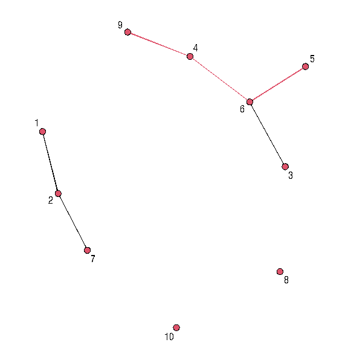

```r
# plot missnet with missing dyads colored red.
tempnet <- missnet
tempnet[4,6] <- tempnet[4,9] <- tempnet[5,6] <- 1
missnetmat <- as.matrix(missnet)
missnetmat[is.na(missnetmat)] <- 2
plot(tempnet,label = network.vertex.names(tempnet),
     edge.col = missnetmat)
```

```r
# fit an ergm to the network with missing data identified
summary(missnet~edges)
```

```
## edges
##     3
```

```r
summary(ergm(missnet~edges))
```

```
## Starting maximum pseudolikelihood estimation (MPLE):
```

```
## Obtaining the responsible dyads.
```

```
## Evaluating the predictor and response matrix.
```

```
## Maximizing the pseudolikelihood.
```

```
## Finished MPLE.
```

```
## Evaluating log-likelihood at the estimate.
```

```
## Call:
## ergm(formula = missnet ~ edges)
##
## Maximum Likelihood Results:
##
##       Estimate Std. Error MCMC % z value Pr(>|z|)
## edges  -2.5649     0.5991      0  -4.281   <1e-04 ***
## ---
## Signif. codes:  0 '***' 0.001 '**' 0.01 '*' 0.05 '.' 0.1 ' ' 1
##
##      Null Deviance: 58.22  on 42  degrees of freedom
##  Residual Deviance: 21.61  on 41  degrees of freedom
##
## AIC: 23.61  BIC: 25.35  (Smaller is better. MC Std. Err. = 0)
```

The coefficient equals -2.56, which corresponds to a probability of 7.14%. Our network has 3 ties, out of the 42 non-missing nodal pairs (10 choose 2 minus 3): 3/42 = 7.14%. So our estimate represents the probability of a tie in the observed sample.

Now let’s assign those missing ties the (observed) value “0” and check how the value of the coefficient will change. Can you predict whether it will get bigger or smaller? Can you calculate it directly before checking the output of an `ergm` fit? Let’s see what happens.

```r
missnet_bad <- missnet # create network with missing dyads set to 0
missnet_bad[4,6] <- missnet_bad[4,9] <- missnet_bad[5,6] <- 0

# fit an ergm to the network with missing dyads set to 0
summary(missnet_bad)
```

```
## Network attributes:
##   vertices = 10
##   directed = FALSE
##   hyper = FALSE
##   loops = FALSE
##   multiple = FALSE
##   bipartite = FALSE
##  total edges = 3
##    missing edges = 0
##    non-missing edges = 3
##  density = 0.06666667
##
## Vertex attributes:
##   vertex.names:
##    character valued attribute
##    10 valid vertex names
##
## No edge attributes
##
## Network adjacency matrix:
##    1 2 3 4 5 6 7 8 9 10
## 1  0 1 0 0 0 0 0 0 0  0
## 2  1 0 0 0 0 0 1 0 0  0
## 3  0 0 0 0 0 1 0 0 0  0
## 4  0 0 0 0 0 0 0 0 0  0
## 5  0 0 0 0 0 0 0 0 0  0
## 6  0 0 1 0 0 0 0 0 0  0
## 7  0 1 0 0 0 0 0 0 0  0
## 8  0 0 0 0 0 0 0 0 0  0
## 9  0 0 0 0 0 0 0 0 0  0
## 10 0 0 0 0 0 0 0 0 0  0
```

```r
summary(ergm(missnet_bad~edges))
```

```
## Starting maximum pseudolikelihood estimation (MPLE):
```

```
## Obtaining the responsible dyads.
```

```
## Evaluating the predictor and response matrix.
```

```
## Maximizing the pseudolikelihood.
```

```
## Finished MPLE.
```

```
## Evaluating log-likelihood at the estimate.
```

```
## Call:
## ergm(formula = missnet_bad ~ edges)
##
## Maximum Likelihood Results:
##
##       Estimate Std. Error MCMC % z value Pr(>|z|)
## edges  -2.6391     0.5976      0  -4.416   <1e-04 ***
## ---
## Signif. codes:  0 '***' 0.001 '**' 0.01 '*' 0.05 '.' 0.1 ' ' 1
##
##      Null Deviance: 62.38  on 45  degrees of freedom
##  Residual Deviance: 22.04  on 44  degrees of freedom
##
## AIC: 24.04  BIC: 25.85  (Smaller is better. MC Std. Err. = 0)
```

The coefficient is smaller now because the missing ties are counted as “0”, and this translates to a conditional tie probability of 6.67%.  
It’s a small difference in this case (and a small network, with little missing data).

MORAL: If you have missing data on ties, be sure to identify them by assigning the “NA” code. This is particularly important if you’re reading in data as an edgelist, as all dyads without edges are implicitly set to “0” in this case.

## 4. Assessing convergence for dyad dependent models: MCMC Diagnostics

When dyad dependent terms are in the model, the computational algorithms in `ergm` use MCMC (with a Metropolis-Hastings sampler) to estimate the parameters.

For these models, it is important to assess model convergence before interpreting the model results – before evaluating statistical significance, interpreting coefficients, or assessing goodness of fit.  
To do this, we use the function `mcmc.diagnostics`.

Below we show a simple example of a model that converges, and how to use the MCMC diagnostics to identify this.

### What it looks like when a model converges properly

We will first consider a simple dyadic dependent model where the algorithm works using the program defaults, with a degree(1) term that captures whether there are more (or less) degree 1 nodes than we would expect, given the density.

```r
summary(flobusiness~edges+degree(1))
```

```
##   edges degree1
##      15       3
```

```r
fit <- ergm(flobusiness~edges+degree(1))
summary(fit)
```

```
## Call:
## ergm(formula = flobusiness ~ edges + degree(1))
##
## Monte Carlo Maximum Likelihood Results:
##
##         Estimate Std. Error MCMC % z value Pr(>|z|)
## edges    -2.1038     0.2800      0  -7.514   <1e-04 ***
## degree1  -0.5628     0.7402      0  -0.760    0.447
## ---
## Signif. codes:  0 '***' 0.001 '**' 0.01 '*' 0.05 '.' 0.1 ' ' 1
##
##      Null Deviance: 166.36  on 120  degrees of freedom
##  Residual Deviance:  89.43  on 118  degrees of freedom
##
## AIC: 93.43  BIC: 99.01  (Smaller is better. MC Std. Err. = 0.03369)
```

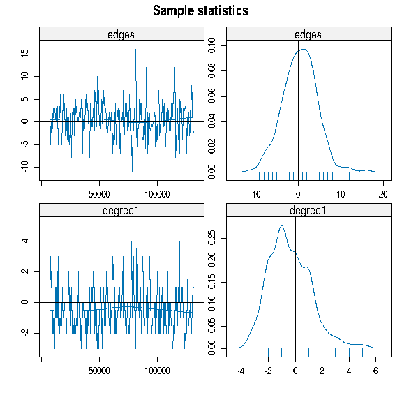

```
## Sample statistics summary:
##
## Iterations = 7168:131072
## Thinning interval = 512
## Number of chains = 1
## Sample size per chain = 243
##
## 1. Empirical mean and standard deviation for each variable,
##    plus standard error of the mean:
##
##            Mean    SD Naive SE Time-series SE
## edges    0.4486 3.994  0.25621         0.2562
## degree1 -0.4033 1.511  0.09693         0.1115
##
## 2. Quantiles for each variable:
##
##         2.5% 25% 50% 75% 97.5%
## edges     -7  -2   0   3     7
## degree1   -3  -1  -1   1     3
##
##
## Are sample statistics significantly different from observed?
##                 edges      degree1       (Omni)
## diff.      0.44855967 -0.403292181           NA
## test stat. 1.75077918 -3.615942344 13.284101750
## P-val.     0.07998395  0.000299257  0.001657501
##
## Sample statistics cross-correlations:
##              edges    degree1
## edges    1.0000000 -0.4396489
## degree1 -0.4396489  1.0000000
##
## Sample statistics auto-correlation:
## Chain 1
##                edges     degree1
## Lag 0     1.00000000  1.00000000
## Lag 512   0.08269575  0.13740188
## Lag 1024 -0.04222338 -0.06091563
## Lag 1536 -0.08709292  0.02710151
## Lag 2048 -0.08232951 -0.08106464
```

[output cut: 8 more lines]

```
##         edges       degree1
## -0.0638761398 -0.0009104091
##
## Individual P-values (lower = worse):
##     edges   degree1
## 0.9490689 0.9992736
## Joint P-value (lower = worse):  0.9982535
##
## Note: MCMC diagnostics shown here are from the last round of
##   simulation, prior to computation of final parameter estimates.
##   Because the final estimates are refinements of those used for
##   this simulation run, these diagnostics may understate model
##   performance. To directly assess the performance of the final
##   model on in-model statistics, please use the GOF command:
##   gof(ergmFitObject, GOF=~model).
```

```r
mcmc.diagnostics(fit)
```

What this shows is statistics from the final iteration of the MCMC chain, on the left as a “traceplot” (the deviation of the statistic value in each sampled network from the observed value), and on the right as the distribution of the sample statistic deviations.

This is what you want to see in the MCMC diagnostics: a “fuzzy caterpillar”. In the last section we’ll look at some models that don’t converge properly, and how to use MCMC diagnostics to identify and address this. There are many control parameters for the MCMC algorithm (“help(control.ergm)”), to improve model convergence.

## 5. Network simulation: the *simulate* command and *network.list* objects

Once we have estimated the coefficients of an ERGM, the model is completely specified. It defines a probability distribution across all networks of this size. If the model is a good fit to the observed data, then networks drawn from this distribution will be more likely to “resemble” the observed data.

```r
flomodel.03.sim <- simulate(flomodel.03,nsim=10)

class(flomodel.03.sim) # what does this produce?
```

```
## [1] "network.list"
```

```r
summary(flomodel.03.sim) # quick summary
```

```
## List of  10  Networks
## Model: flomarriage ~ edges + nodecov("wealth")
## Reference: ~Bernoulli
## Constraints: ~. ~. - observed
## Stored network statistics:
##       edges nodecov.wealth
##  [1,]    23           2259
##  [2,]    22           2316
##  [3,]    27           2506
##  [4,]    26           2668
##  [5,]    24           2468
##  [6,]    20           1907
##  [7,]    22           2326
##  [8,]    13           1671
##  [9,]    27           3054
## [10,]    20           2397
## attr(,"monitored")
## [1] FALSE FALSE
```

```
## List of  10  Networks
## Model: flomarriage ~ edges + nodecov("wealth")
## Reference: ~Bernoulli
## Constraints: ~. ~. - observed
```

```r
attributes(flomodel.03.sim) # what's in this object?
```

```
## $coefficients
##          edges nodecov.wealth
##    -2.59492903     0.01054591
##
## $control
## Control parameter list generated by 'control.simulate.formula' or equivalent. Non-empty parameters:
## MCMC.burnin: 16384
## MCMC.interval: 1024
## MCMC.scale: 1
## MCMC.prop: ~sparse + .triadic
## MCMC.prop.weights: "default"
## MCMC.batch: 0
## MCMC.effectiveSize.damp: 10
## MCMC.effectiveSize.maxruns: 1000
## MCMC.effectiveSize.burnin.pval: 0.2
## MCMC.effectiveSize.burnin.min: 0.05
## MCMC.effectiveSize.burnin.max: 0.5
## MCMC.effectiveSize.burnin.nmin: 16
## MCMC.effectiveSize.burnin.nmax: 128
## MCMC.effectiveSize.burnin.PC: FALSE
## MCMC.effectiveSize.burnin.scl: 1024
## MCMC.maxedges: Inf
## MCMC.runtime.traceplot: FALSE
## network.output: "network"
## parallel: 0
## parallel.version.check: TRUE
## parallel.inherit.MT: FALSE
## MCMC.samplesize: 10
## obs.MCMC.mul: 0.25
## obs.MCMC.samplesize.mul: 0.5
## obs.MCMC.interval.mul: 0.5
## obs.MCMC.burnin.mul: 0.5
## obs.MCMC.prop: ~sparse + .triadic
## obs.MCMC.prop.weights: "default"
## MCMC.save_networks: TRUE
##
## $response
## [1] NA
##
## $class
```

[output cut: 34 more lines]

```
## No edge attributes
##
## $constraints
## $constraints[[1]]
## ~.
## <environment: base>
##
## $constraints[[2]]
## ~. - observed
## <environment: base>
##
##
## $reference
## ~Bernoulli
## <environment: base>
```

```r
# are the simulated stats centered on the observed stats?
rbind("obs"=summary(flomarriage~edges+nodecov("wealth")),
      "sim mean"=colMeans(attr(flomodel.03.sim, "stats")))
```

```
##          edges nodecov.wealth
## obs       20.0         2168.0
## sim mean  22.4         2357.2
```

```r
# we can also plot individual simulations
flomodel.03.sim[[1]]
```

```
##  Network attributes:
##   vertices = 16
##   directed = FALSE
##   hyper = FALSE
##   loops = FALSE
##   multiple = FALSE
##   bipartite = FALSE
##   total edges= 23
##     missing edges= 0
##     non-missing edges= 23
##
##  Vertex attribute names:
##     priorates totalties vertex.names wealth
##
## No edge attributes
```

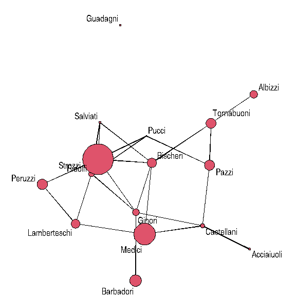

```r
plot(flomodel.03.sim[[1]],
     label= flomodel.03.sim[[1]] %v% "vertex.names",
     vertex.cex = (flomodel.03.sim[[1]] %v% "wealth")/25)
```

Voila. Of course, yours will look somewhat different.

## 6. Examining the quality of model fit – GOF

ERGMs can be seen as generative models when they represent the process that governs the global patterns of tie prevalence from a local perspective: the perspective of the nodes involved in the particular micro-configurations represented by the `ergm` terms in the model. The locally generated processes in turn aggregate up to produce characteristic global network properties, even though these global properties are not explicit terms in the model.

One test of whether a local model “fits the data” is therefore how well it reproduces the observed global network properties *that are not in the model*. We do this by choosing a network statistic that is not in the model, and comparing the value of this statistic observed in the original network to the distribution of values we get in simulated networks from our model, using the **gof** function.

The **gof** function is a bit different than the **summary**, **ergm**, and **simulate** functions, in that it currently only takes 3 `ergm` terms as arguments: degree, esp (edgwise share partners), and distance (geodesic distances). Each of these terms captures an aggregate network distribution, at either the node level (degree), the edge level (esp), or the dyad level (distance).

```r
flomodel.03.gof <- gof(flomodel.03)
flomodel.03.gof
```

```
##
## Goodness-of-fit for model statistics
##
##                 obs min    mean  max MC p-value
## edges            20   7   20.30   32       1.00
## nodecov.wealth 2168 832 2216.59 3662       0.98
##
## Goodness-of-fit for minimum geodesic distance
##
##     obs min  mean max MC p-value
## 1    20   7 20.30  32       1.00
## 2    35   4 34.32  59       0.86
## 3    32   3 26.92  43       0.60
## 4    15   0 11.92  24       0.60
## 5     3   0  4.01  15       1.00
## 6     0   0  1.27  11       1.00
## 7     0   0  0.50  10       1.00
## 8     0   0  0.11   6       1.00
## 9     0   0  0.04   3       1.00
## Inf  15   0 20.61 103       1.00
##
## Goodness-of-fit for degree
##
##    obs min mean max MC p-value
## 0    1   0 1.12   6       1.00
## 1    4   0 3.27   8       0.98
## 2    2   1 4.51   9       0.34
## 3    6   0 3.31   8       0.20
## 4    2   0 1.90   6       1.00
## 5    0   0 1.07   4       0.72
## 6    1   0 0.49   3       0.84
## 7    0   0 0.20   2       1.00
## 8    0   0 0.09   1       1.00
## 9    0   0 0.03   1       1.00
## 10   0   0 0.01   1       1.00
##
## Goodness-of-fit for edgewise shared partner
##
##   obs min  mean max MC p-value
## 0  12   4 11.95  20       1.00
## 1   7   0  6.28  16       0.96
## 2   1   0  1.67   8       1.00
## 3   0   0  0.34   5       1.00
## 4   0   0  0.05   1       1.00
## 5   0   0  0.01   1       1.00
```

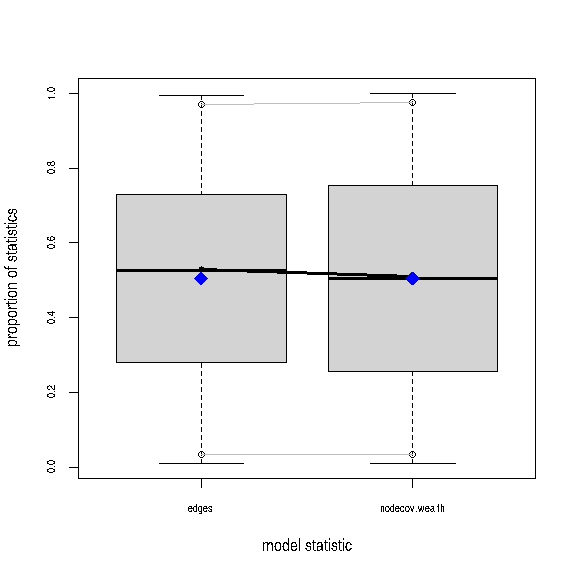

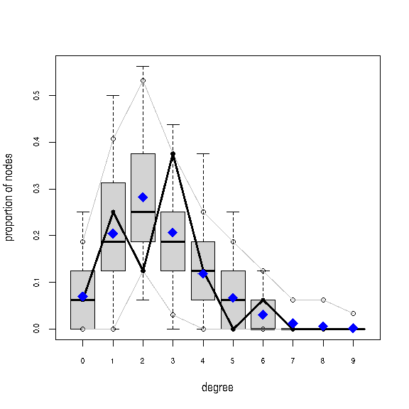

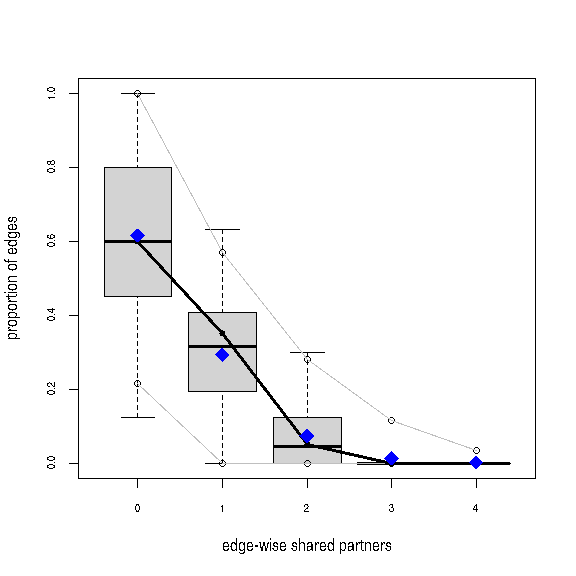

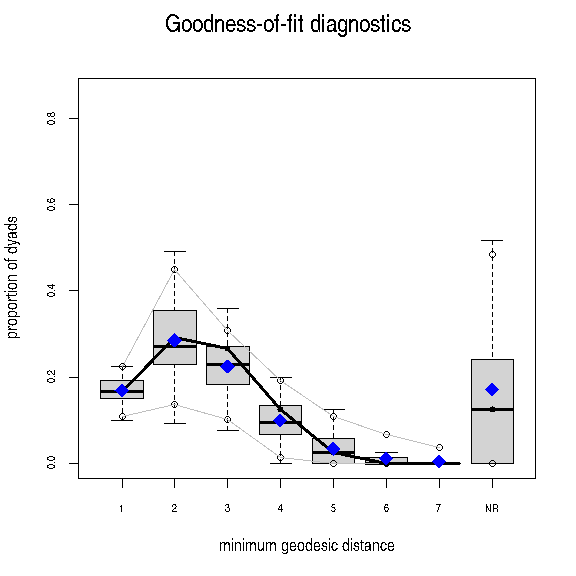

```r
plot(flomodel.03.gof)
```

```r
mesamodel.02 <- ergm(mesa~edges)
```

```
## Starting maximum pseudolikelihood estimation (MPLE):
```

```
## Obtaining the responsible dyads.
```

```
## Evaluating the predictor and response matrix.
```

```
## Maximizing the pseudolikelihood.
```

```
## Finished MPLE.
```

```
## Evaluating log-likelihood at the estimate.
```

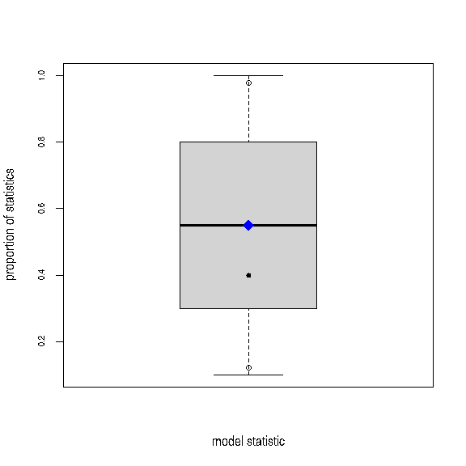

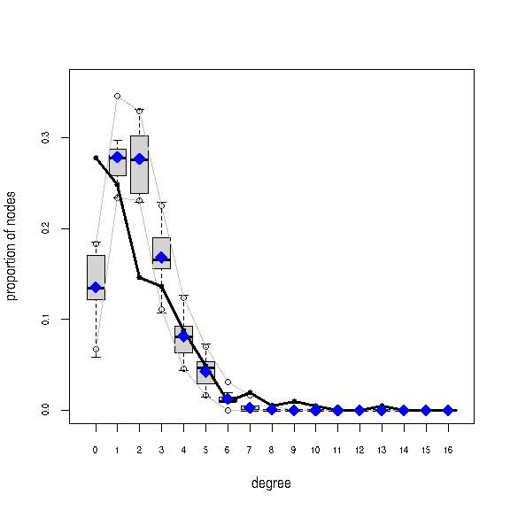

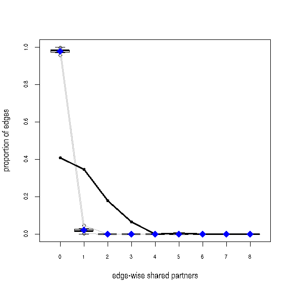

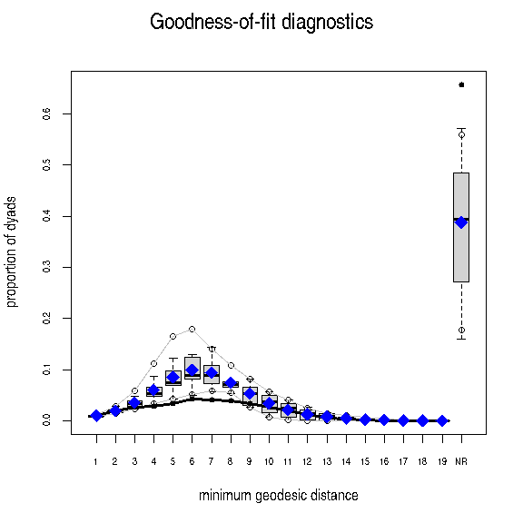

```r
mesamodel.02.gof <- gof(mesamodel.02~degree + esp + distance,
                        control = control.gof.ergm(nsim=10))
plot(mesamodel.02.gof)
```

For a good example of model exploration and fitting for the Add Health Friendship networks, see Goodreau, Kitts, and Morris (2009). For more technical details on the approach, see Hunter, Goodreau, and Handcock (2008).

## 7. Diagnostics: troubleshooting and checking for model degeneracy

When a model is not a good representation of the observed network, the simulated networks produced in the MCMC chains may be far enough away from the observed network that the estimation process is affected. In the worst case scenario, the simulated networks will be so different that the algorithm fails altogether. When this happens, it basically means the model you specified would not have produced the network you observed. Some models, we now know, would almost never produce an interesting network with this density – this is what we call “model degneracy.”

For more detailed discussion of model degeneracy in the ERGM context, see Handcock (2003), Snijders et al. (2006), and Schweinberger (2011).

In that worst case scenario, we end up not being able to obtain coefficent estimates, so we can’t use the GOF function to identify how the model simulations deviate from the observed data. We can, however, still use the MCMC diagnostics to observe what is happening with the simulation algorithm, and this (plus some experience and intuition about the behavior of `ergm` terms) can help us improve the model specification.

The computational algorithms in `ergm` use MCMC to estimate the likelihood function. Part of this process involves simulating a set of networks to approximate unknown components of the likelihood.

When a model is not a good representation of the observed network the estimation process may be affected. In the worst case scenario, the simulated networks will be so different from the observed network that the algorithm fails altogether. This can occur for two general reasons. First, the simulation algorithm may fail to converge, and the sampled networks are thus not from the specified distribution. Second, the model parameters used to simulate the networks are too different from the MLE, so even though the simulation algorithm is producing a representative sample of networks, this is not the sample that would be produced under the MLE.

For more detailed discussions of model degeneracy in the ERGM context, see the papers in *J Stat Software* v. 24. (link is available online at (www.statnet.org))

We can use diagnostics to see what is happening with the simulation algorithm, and these can lead us to ways to improve it.

We will first consider a simulation where the algorithm works. To understand the algorithm, consider

```r
fit <- ergm(flobusiness~edges+degree(1),
  control=control.ergm(MCMC.interval=1, MCMC.burnin=1000, seed=1))
```

This runs a version with every network returned. Let us look at the diagnostics produced:

```r
mcmc.diagnostics(fit, center=F)
```

Let’s look more carefully at a default model fit:

```r
fit <- ergm(flobusiness~edges+degree(1))
mcmc.diagnostics(fit, center=F)
```

Now let us look at a more interesting case, using a larger network:

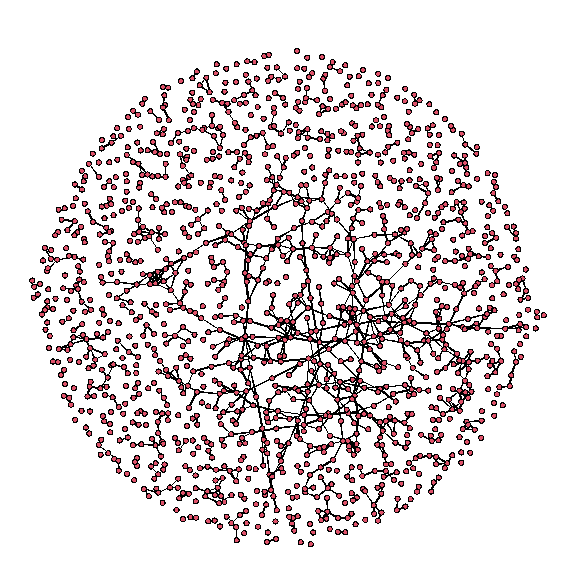

```r
data('faux.magnolia.high')
magnolia <- faux.magnolia.high
plot(magnolia, vertex.cex=.5)
```

```r
fit <- ergm(magnolia~edges+triangle, control=control.ergm(seed=1))
```

```
## Starting maximum pseudolikelihood estimation (MPLE):
```

```
## Obtaining the responsible dyads.
```

```
## Evaluating the predictor and response matrix.
```

```
## Maximizing the pseudolikelihood.
```

```
## Finished MPLE.
```

```
## Starting Monte Carlo maximum likelihood estimation (MCMLE):
```

```
## Iteration 1 of at most 60:
```

```
## Error in `ergm.MCMLE()`:
## ! Number of edges in a simulated network exceeds that in the observed by a factor of more than 20. This is a strong indicator of model degeneracy or a very poor starting parameter configuration. If you are reasonably certain that neither of these is the case, increase the MCMLE.density.guard cont…
```

Very interesting. This model produced degenerate networks. You could have gotten some more feedback about this during the fitting, by using:

```r
fit <- ergm(magnolia~edges+triangle, control=control.ergm(seed=1), verbose=T)
```

One approach to solving model degeneracy would be to modify the parameters of MCMC algorithm. As one example, increasing the MCMC sample size can sometimes help:

```r
fit <- ergm(magnolia~edges+triangle,seed=1,
 control = control.ergm(seed=1, MCMC.samplesize=20000),
 verbose=T)
mcmc.diagnostics(fit, center=F)
```

But it does not solve the problem in this case, and in general this type of degeneracy is unlikely to be fixed by tuning the MCMC parameters.

How about trying a different model specification: use GWESP, the more robust approach to modeling triangles? (For a technical introduction to GWESP see Hunter 2007; for a more intuitive description and empirical application see Goodreau Kitts and Morris 2009 in the references.)

Note that we are running with a somewhat lower precision than the default, to save time.

```r
fit <- ergm(magnolia~edges+gwesp(0.5,fixed=T)+nodematch('Grade')+nodematch('Race')+
  nodematch('Sex'),
 control =  control.ergm(seed=1, MCMLE.MCMC.precision=2))
mcmc.diagnostics(fit)
```

One more try…

```r
fit <- ergm(magnolia~edges+gwesp(0.25,fixed=T)+nodematch('Grade')+nodematch('Race')+
  nodematch('Sex'),
 control = control.ergm(seed=1, MCMLE.MCMC.precision=2),
 verbose=T)
```

```
## Evaluating network in model.
```

[output not shown]

[output cut: 53 more lines]

[output not shown]

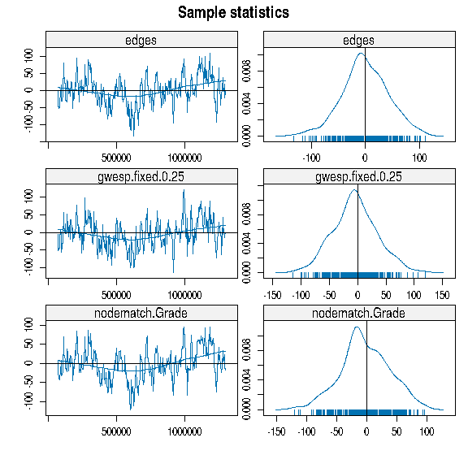

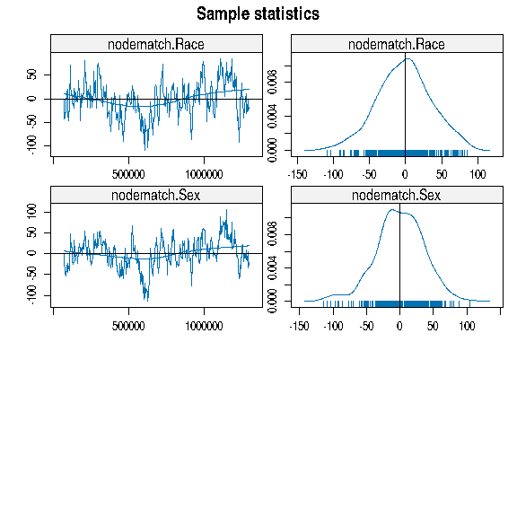

```
## Sample statistics summary:
##
## Iterations = 69632:1298432
## Thinning interval = 4096
## Number of chains = 1
## Sample size per chain = 301
##
## 1. Empirical mean and standard deviation for each variable,
##    plus standard error of the mean:
##
##                     Mean    SD Naive SE Time-series SE
## edges            -0.3056 42.47    2.448          6.993
## gwesp.fixed.0.25 -4.3498 39.42    2.272          7.525
## nodematch.Grade  -2.5116 40.73    2.348          7.188
## nodematch.Race   -1.6977 37.20    2.144          5.995
## nodematch.Sex    -0.1362 35.79    2.063          6.932
##
## 2. Quantiles for each variable:
##
##                    2.5%    25%    50%   75% 97.5%
## edges            -92.00 -26.00 -3.000 26.00 81.50
## gwesp.fixed.0.25 -76.19 -28.29 -4.756 20.46 73.31
## nodematch.Grade  -83.50 -25.00 -8.000 24.00 72.50
## nodematch.Race   -76.50 -26.00  0.000 23.00 71.00
## nodematch.Sex    -81.50 -21.00  0.000 24.00 65.00
##
##
## Are sample statistics significantly different from observed?
##                  edges gwesp.fixed.0.25 nodematch.Grade nodematch.Race
## diff.      -0.30564784       -4.3497703      -2.5116279     -1.6976744
## test stat. -0.04370733       -0.5780192      -0.3494084     -0.2832045
## P-val.      0.96513769        0.5632512       0.7267827      0.7770201
##            nodematch.Sex      (Omni)
## diff.        -0.13621262          NA
## test stat.   -0.01964918 11.03863445
## P-val.        0.98432323  0.06932526
##
## Sample statistics cross-correlations:
##                      edges gwesp.fixed.0.25 nodematch.Grade nodematch.Race
## edges            1.0000000        0.8574745       0.9484522      0.9388034
```

[output cut: 38 more lines]

```
##
## Individual P-values (lower = worse):
##            edges gwesp.fixed.0.25  nodematch.Grade   nodematch.Race
##       0.06736203       0.48827755       0.18208798       0.17777223
##    nodematch.Sex
##       0.07369277
## Joint P-value (lower = worse):  0.1495111
##
## Note: MCMC diagnostics shown here are from the last round of
##   simulation, prior to computation of final parameter estimates.
##   Because the final estimates are refinements of those used for
##   this simulation run, these diagnostics may understate model
##   performance. To directly assess the performance of the final
##   model on in-model statistics, please use the GOF command:
##   gof(ergmFitObject, GOF=~model).
```

```r
mcmc.diagnostics(fit)
```

Success! Of course, in real life one might have a lot more trial and error.

Degeneracy is often an indicator of a poorly specified model. It is not a property of all ERGMs, but it is associated with some dyadic-dependent terms, in particular, the reduced homogenous Markov specifications (e.g., 2-stars and triangle terms). For a good technical discussion of unstable terms see Schweinberger (2011). For a discussion of alternative terms that exhibit more stable behavior see Snijders et al. (2006) and for the `gwesp` term (and the curved exponential family terms in general) see Hunter and Handcock (2006).

## 8. Working with egocentrically sampled network data

One of the most powerful features of ERGMs is that they can be used to estimate models from from egocentrically sampled data, and the fitted models can then be used to simulate complete networks (of any size) that will have the properties of the original network that are observed and represented in the model.

The egocentric estimation/simulation framework extends to temporal ERGMs (“TERGMs”) as well, with the minimal addition of an estimate of partnership duration. This makes it possible to simulate complete dynamic networks from a single cross-sectional egocentrically sampled network. For an example of what you can do with this, check out the network movie we developed to explore the impact of dynamic network structure on HIV transmission, see https://statnet.org/movies/ .

While the `ergm` package can be used with egocentric data, we recommend instead to use the package `ergm.ego`. This package includes accurate statistical inference and many utilities that simplify the task of reading in the data, conducting exploratory analyses, calculating the sample “target statistics”, and specifying model options.

We have a workshop/tutorial for `ergm.ego` at the [statnet Workshops site](https://statnet.org/workshops/).

## 9. Additional functionality in statnet and other package

`statnet` is a suite of packages that are designed to work together, and provide tools for a wide range of different types of network data analysis. Examples include temporal network models and dynamic network vizualizations, multilevel network modeling, latent cluster models and network diffusion and epidemic models. Development is ongoing, and there are new packages, and new functionality added to existing packages on a regular basis.

All of these packages can be downloaded from CRAN. For more detailed information, please visit the `statnet` webpage [www.statnet.org](https://statnet.org/).

### Current statnet packages

Packages developed by statnet team that are not covered in this tutorial:

- `sna` – classical social network analysis utilities
- `tsna` – descriptive statistics for temporal network data
- `tergm` – temporal ERGMs for dynamic networks
- `ergm.ego`– estimation/simulation of ergms from egocentrically sampled data
- `ergm.count` – models for tie count network data
- `ergm.rank` – models for tie rank network data
- `ergm.multi` – models of multilayer networks and for samples of networks
- `relevent` – relational event models for networks
- `latentnet` – latent space and latent cluster analysis
- `degreenet` – MLE estimation for degree distributions (negative binomial, Poisson, scale-free, etc.)
- `networksis` – simulation of bipartite networks with given degree distributions
- `ndtv` – network movie maker
- `EpiModel` – network modeling of infectious disease and social diffusion processes

### Additional functionality in base `ergm`

- ERGMs for valued ties

### Extensions by other developers

There are now a number of excellent packages developed by others that extend the functionality of statnet. The easiest way to find these is to look at the “reverse depends” of the `ergm` package on CRAN. Examples include:

- `Bergm` – Bayesian Exponential Random Graph Models
- `btergm` – Temporal Exponential Random Graph Models by Bootstrapped Pseudolikelihood
- `hergm` – hierarchical ERGMs for multi-level network data
- `xergm` – extensions to ERGM modeling

### The `statnet` development team

Pavel N. Krivitsky p.krivitsky@unsw.edu.au  
Martina Morris morrism@u.washington.edu  
Mark S. Handcock handcock@stat.ucla.edu  
David R. Hunter dhunter@stat.psu.edu  
Carter T. Butts buttsc@uci.edu  
Steven M. Goodreau goodreau@u.washington.edu  
Skye Bender-deMoll skyebend@skyeome.net  
Samuel M. Jenness samuel.m.jenness@emory.edu

## Further reading

The best place to start is the special issue of the *Journal of Statistical Software* (JSS) devoted to `statnet`: [link](https://www.jstatsoft.org/issue/view/v024)

The nine papers in this issue cover a wide range of theoretical and practical topics related to ERGMs, and their implementation in `statnet`.

HOWEVER: Note that this issue was written in 2008. The statnet code base has evolved considerably since that time, so some of the syntax specified in the articles may no longer work (in most cases because it has been replace with something better).

An overview of most recent update, `ergm 4`, can be found at Krivitsky et al. (2023).

For social scientists, a good introductory application paper is Goodreau, Kitts, and Morris (2009).

### Dealing with Model Degeneracy

Handcock (2003)

Schweinberger (2011)

Snijders et al. (2006)

Hunter (2007)

### Temporal ERGMs

Krivitsky and Handcock (2014)

### Egocentric ERGMS

Krivitsky, Handcock, and Morris (2011)

Krivitsky and Morris (2017)

## References

Goodreau, Steven M., James A. Kitts, and Martina Morris. 2009. “Birds of a Feather, or Friend of a Friend? Using Exponential Random Graph Models to Investigate Adolescent Social Networks.” *Demography* 46 (1): 103–25. https://doi.org/10.1353/dem.0.0045.

Handcock, Mark S. 2003. “Assessing Degeneracy in Statistical Models of Social Networks.” Working Paper 39. Seattle, WA: Center for Statistics; the Social Sciences, University of Washington. https://csss.uw.edu/research/working-papers/assessing-degeneracy-statistical-models-social-networks.

Hunter, David R. 2007. “Curved Exponential Family Models for Social Networks.” *Social Networks* 29: 216–30. https://doi.org/10.1016/j.socnet.2006.08.005.

Hunter, David R., Steven M. Goodreau, and Mark S. Handcock. 2008. “Goodness of Fit for Social Network Models.” *Journal of the American Statistical Association* 103 (481): 248–58. https://doi.org/10.1198/016214507000000446.

———. 2013. “Ergm.userterms: A Template Package for Extending Statnet.” *Journal of Statistical Software* 52 (2): 1–25. https://doi.org/10.18637/jss.v052.i02.

Hunter, David R., and Mark S. Handcock. 2006. “Inference in Curved Exponential Family Models for Networks.” *Journal of Computational and Graphical Statistics* 15 (3): 565–83. https://doi.org/10.1198/106186006X133069.

Krivitsky, Pavel N., and Mark S. Handcock. 2014. “A Separable Model for Dynamic Networks.” *Journal of the Royal Statistical Society, Series B* 76 (1): 29–46. https://doi.org/10.1111/rssb.12014.

Krivitsky, Pavel N., Mark S. Handcock, and Martina Morris. 2011. “Adjusting for Network Size and Composition Effects in Exponential-Family Random Graph Models.” *Statistical Methodology* 8 (4): 319–39. https://doi.org/10.1016/j.stamet.2011.01.005.

Krivitsky, Pavel N., David R. Hunter, Martina Morris, and Chad Klumb. 2023. “ergm 4: New Features for Analyzing Exponential-Family Random Graph Models.” *Journal of Statistical Software* 105 (6): 1–44. https://doi.org/10.18637/jss.v105.i06.

Krivitsky, Pavel N., and Martina Morris. 2017. “Inference for Social Network Models from Egocentrically-Sampled Data, with Application to Understanding Persistent Racial Disparities in HIV Prevalence in the US.” *Annals of Applied Statistics* 11 (1): 427–55. https://doi.org/10.1214/16-AOAS1010.

Morris, Martina, Mark S. Handcock, and David R. Hunter. 2008. “Specification of Exponential-Family Random Graph Models: Terms and Computational Aspects.” *Journal of Statistical Software* 24 (4): 1–24. https://doi.org/10.18637/jss.v024.i04.

Schweinberger, Michael. 2011. “Instability, Sensitivity, and Degeneracy of Discrete Exponential Families.” *Journal of the American Statistical Association* 106 (496): 1361–70. https://doi.org/10.1198/jasa.2011.tm10747.

Snijders, Tom A. B., Philippa E. Pattison, Garry L. Robins, and Mark S. Handcock. 2006. “New Specifications for Exponential Random Graph Models.” *Sociological Methodology* 36 (1): 99–153. https://doi.org/10.1111/j.1467-9531.2006.00176.x.